# Introduction to Statistical Learning - Chapter 7

## Question 1

1. When $x \leq \xi$, $(x-\xi)^3 = 0$, and $f(x) = \beta_0 + \beta_1 x + \beta_2 x^2 + \beta_3 x^3$. So $a_1 = \beta_0$, $b_1 = \beta_1$, $c_1 = \beta_2$, and $d_1 = \beta_3$.
2. When $x \gt \xi$, $f(x) = \beta_0 + \beta_1 x + \beta_2 x^2 + \beta_3 x^3 + \beta_4 (x-\xi)^3 \\ = \beta_0 + \beta_1 x + \beta_2 x^2 + \beta_3 x^3 + \beta_4 (x^3-3 x^2 \xi + 3 x \xi^2 - \xi^3) \\ = \beta_0 - \beta_4 \xi^3 + x(\beta_1 + 3 \beta_4 \xi^2) + x^2 (\beta_2 - 3 \beta_4 \xi) + x^3(\beta_3+\beta_4) \\$ So, $a_2 = \beta_0 - \beta_4 \xi^3$, $b_2 = (\beta_1 + 3 \beta_4 \xi^2)$, $c_2 = (\beta_2 - 3 \beta_4 \xi)$, and $d_2 = \beta_3 + \beta_4$. Or we can write these in terms of the coefficients for $f_1(x)$ as $a_2 = a_1 - \beta_4 \xi^3$, $b_2 = (b_1 + 3 \beta_4 \xi^2)$, $c_2 = (c_1 - 3 \beta_4 \xi)$, and $d_2 = d_1 + \beta_4$.
3. $f_1(\xi) = a_1 + b_1 \xi + c_1 \xi^2 + d_1 \xi^3 \\$ and $f_2(\xi) = a_1 - \beta_4 \xi^3 + \xi (b_1 + 3 \beta_4 \xi^2) + \xi^2 (c_1 - 3 \beta_4 \xi) + \xi^3(d_1+\beta_4) \\ = a_1 - \beta_4 \xi^3 + b_1 \xi + 3 \beta_4 \xi^3 + c_1 \xi^2 - 3 \beta_4 \xi^3 + d_1 \xi^3 + \beta_4 \xi^3 \\ = a_1 + b_1 \xi + c_1 \xi^2 + d_1 \xi^3 = f_1(\xi)\\$
4. $f_1'(x) = b_1 + 2 c_1 x + 3 d_1 x^2 \\ f_1'(\xi) = b_1 + 2 c_1 \xi + 3 d_1 \xi^2$ and $f_2'(x) = b_2 + 2 c_2 x + 3 d_2 x^2 \\ = (b_1 + 3 \beta_4 \xi^2) + 2 (c_1 - 3 \beta_4 \xi) x + 3 (d_1 + \beta_4) x^2 \\ f_2'(\xi) = (b_1 + 3 \beta_4 \xi^2) + 2 (c_1 - 3 \beta_4 \xi) \xi + 3 (d_1 + \beta_4) \xi^2 \\ = (b_1 + 3 \beta_4 \xi^2) + 2 c_1 \xi - 6 \beta_4 \xi^2 + 3 d_1 \xi^2 + 3 \beta_4 \xi^2 \\ = b_1 + 2 c_1 \xi + 3 d_1 \xi^2 \\$  
   e. $f_1''(x) = 2 c_1 + 6 d_1 x \\ f_1''(\xi) = 2 c_1 + 6 d_1 \xi \\$ and $f_2'(x) = 2 c_2 + 6 d_2 x \\ = 2 (c_1 - 3 \beta_4 \xi) + 6 (d_1 + \beta_4) x \\ f_2'(\xi) = 2 (c_1 - 3 \beta_4 \xi) + 6 (d_1 + \beta_4) \xi \\ = 2 c_1 - 6 \beta_4 \xi + 6 d_1 + 6 \beta_4 \xi \\ = 2 c_1 + 6 d_1 \xi \\$

## Question 2

1. When $\lambda = \infty$, the first term is ignored, only the smoothness of the function (second term) matters. When $m=0$, $\int \left[ g^{m}(x) \right]^2 dx = \int g(x)^2 dx$, which will be minimized when $g(x)=0$.
2. When $m=1$, second term is $\int \left[ g'(x) \right]^2 dx$, which means that we want to minimize the first derivative. The first derivative is 0 when the function is constant. So the optimal solution will be the function of the form $g(x) = c$ that minimizes the first term. In other words, $c$ will be the mean output.
3. When $m=2$, we want to minimize the second derivative. The second derivative of functions of the form $g(x) = \beta_0 + \beta_1 x$ is 0. Hence, the optimal solution will be the best line fit to the data.
4. With a similar argument, the optimal solution will be the best second degree polynomial fit to the data.
5. Since $\lambda=0$, second term does not matter. The solution will be the function $g(x)$ that goes through all the data points.

## Question 5

1. $\hat{g}_2$ is a more flexible model, because the fourth derivative is minimized leading to a third degree polynomial. For $\hat{g}_1$, the third derivative is minimized, which leads to a second degree polynomial. Thus, the training RSS will be lower for the more flexible model, $\hat{g}_2$.
2. The test RSS depends on the data we have; we cannot say anything about it.
3. For $\lambda=0$, the two problems are the same; hence will give us the same solution.

## Question 9

1. Let us load the data and fit polynomial regression.

```r
library(MASS)
lm.fit = lm(nox~poly(dis, 3), data=Boston)
summary(lm.fit)
```

```
##
## Call:
## lm(formula = nox ~ poly(dis, 3), data = Boston)
##
## Residuals:
##      Min       1Q   Median       3Q      Max
## -0.12113 -0.04062 -0.00974  0.02338  0.19490
##
## Coefficients:
##               Estimate Std. Error t value Pr(>|t|)
## (Intercept)    0.55470    0.00276  201.02  < 2e-16 ***
## poly(dis, 3)1 -2.00310    0.06207  -32.27  < 2e-16 ***
## poly(dis, 3)2  0.85633    0.06207   13.80  < 2e-16 ***
## poly(dis, 3)3 -0.31805    0.06207   -5.12  4.3e-07 ***
## ---
## Signif. codes:  0 '***' 0.001 '**' 0.01 '*' 0.05 '.' 0.1 ' ' 1
##
## Residual standard error: 0.0621 on 502 degrees of freedom
## Multiple R-squared:  0.715,  Adjusted R-squared:  0.713
## F-statistic:  419 on 3 and 502 DF,  p-value: <2e-16
```

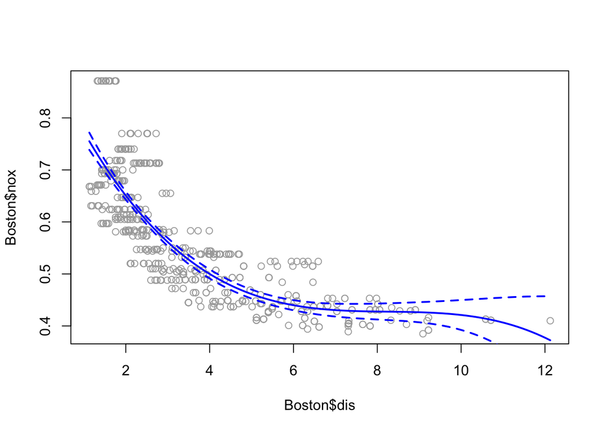

```r
plot(Boston$dis, Boston$nox, col='darkgrey')
dis.range = range(Boston$dis)
dis.grid = seq(from=dis.range[1], to=dis.range[2], length.out = 100)
pred.grid = predict(lm.fit, newdata=data.frame(dis=dis.grid), se=T)
lines(dis.grid, pred.grid$fit, col='blue', lwd=2)
lines(dis.grid, pred.grid$fit + 2*pred.grid$se.fit, col='blue', lwd=2, lty='dashed')
lines(dis.grid, pred.grid$fit - 2*pred.grid$se.fit, col='blue', lwd=2, lty='dashed')
```

2. Fit polynomials of degree 1 to 10.

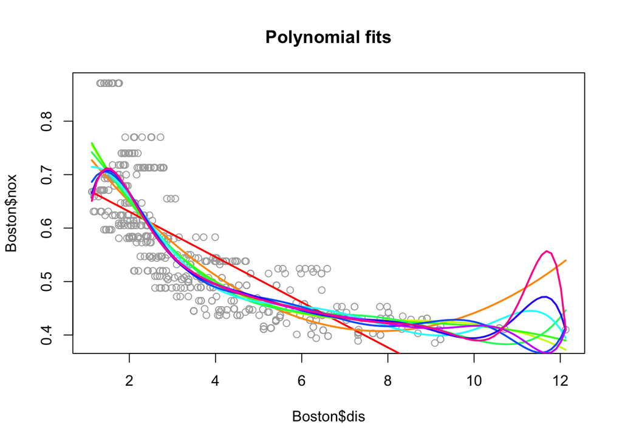

```r
fit_predict_poly = function(degree){
  lm.fit = lm(nox~poly(dis, degree), data=Boston)
  pred = predict(lm.fit, newdata=data.frame(dis=dis.grid), se=T)
  rss = summary(lm.fit)[[6]]
  list(pred=pred, rss=rss)
}

lm.fits = sapply(X = 1:10, FUN = fit_predict_poly)
plot(Boston$dis, Boston$nox, col='darkgrey')
title('Polynomial fits')
for( i in 1:10 ){
  col = rainbow(n = 10)[i]
  lines(dis.grid, lm.fits[[1,i]]$fit, lwd=2, col=col)
  #lines(dis.grid, lm.fits[[1,i]]$fit + 2*lm.fits[[1,i]]$se.fit, lwd=2, lty='dashed', col=col)
  #lines(dis.grid, lm.fits[[1,i]]$fit - 2*lm.fits[[1,i]]$se.fit, lwd=2, lty='dashed', col=col)
}
```

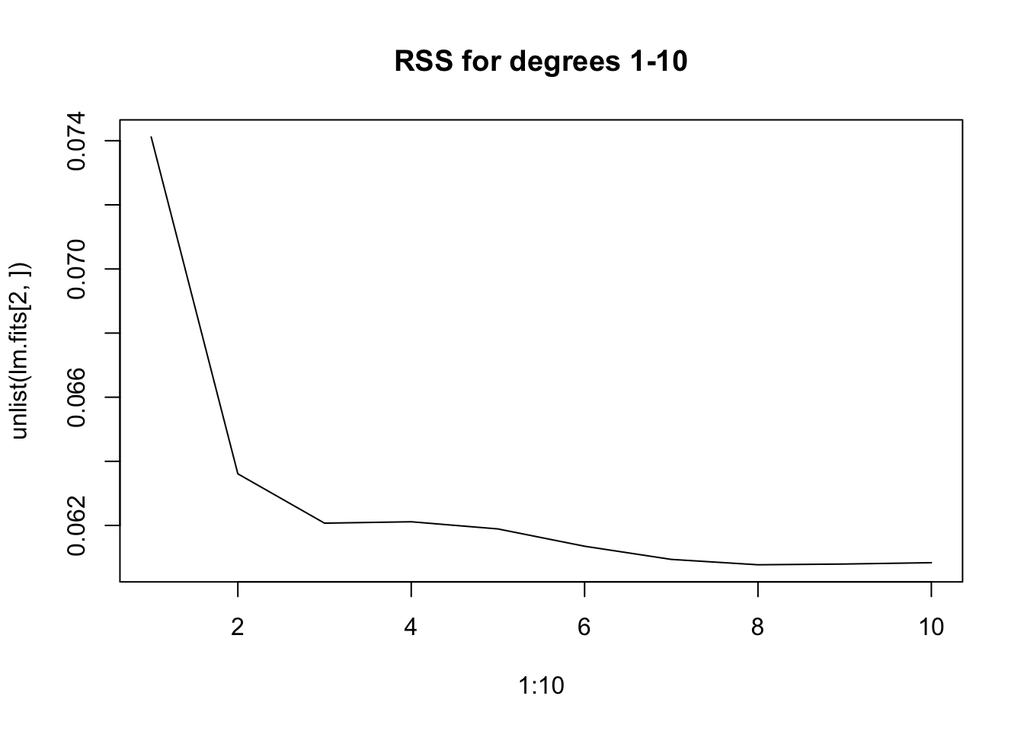

```r
plot(1:10, unlist(lm.fits[2, ]), type = 'l')
title('RSS for degrees 1-10')
```

3. Run 10-fold cross validation for polynomials of degree 1 to 10.

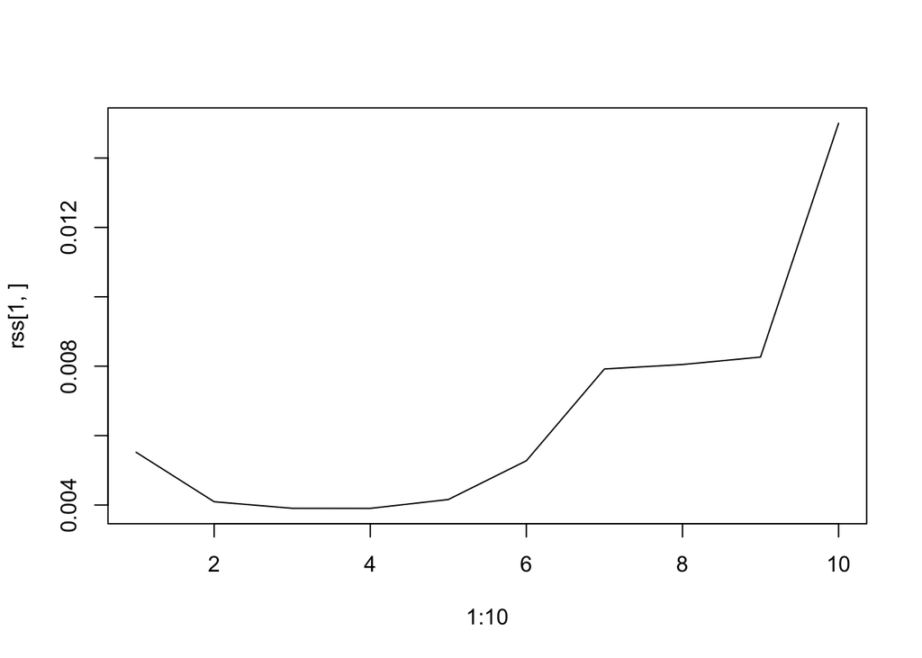

```r
cv.lm = function(degree, k, seed){
  set.seed(seed)
  folds = sample(1:k, nrow(Boston), rep=T)
  rss = rep(0, k)
  for( i in 1:k ){
    fit = lm(nox~poly(dis, degree), data = Boston[folds!=i,])
    pred = predict(fit, newdata=Boston[folds==i,])
    rss[i] = mean((Boston[folds==i, 'nox'] - pred)^2)
  }
  data.frame(rss=mean(rss), sd_rss = sd(rss))
}

seed = 1
k = 10
rss = sapply(1:10, function(d){ cv.lm(d, k, seed)})
# ylim = c(min(unlist(rss[1,])-unlist(rss[2,])), max(unlist(rss[1,])+unlist(rss[2,])))
plot(1:10, rss[1,], type='l')
```

```r
# segments(1:10, unlist(rss[1,])-unlist(rss[2,]), 1:10, unlist(rss[1,])+unlist(rss[2,]))
which.min(rss[1,])
```

```
## [1] 4
```

1. Use regression splines with 4 degrees of freedom.

```r
library(splines)
bs.fit = lm(nox~bs(dis, df=4), data=Boston)
summary(bs.fit)
```

```
##
## Call:
## lm(formula = nox ~ bs(dis, df = 4), data = Boston)
##
## Residuals:
##      Min       1Q   Median       3Q      Max
## -0.12462 -0.03926 -0.00851  0.02085  0.19389
##
## Coefficients:
##                  Estimate Std. Error t value Pr(>|t|)
## (Intercept)        0.7345     0.0146   50.31  < 2e-16 ***
## bs(dis, df = 4)1  -0.0581     0.0219   -2.66   0.0081 **
## bs(dis, df = 4)2  -0.4636     0.0237  -19.60  < 2e-16 ***
## bs(dis, df = 4)3  -0.1998     0.0431   -4.63  4.6e-06 ***
## bs(dis, df = 4)4  -0.3888     0.0455   -8.54  < 2e-16 ***
## ---
## Signif. codes:  0 '***' 0.001 '**' 0.01 '*' 0.05 '.' 0.1 ' ' 1
##
## Residual standard error: 0.062 on 501 degrees of freedom
## Multiple R-squared:  0.716,  Adjusted R-squared:  0.714
## F-statistic:  316 on 4 and 501 DF,  p-value: <2e-16
```